# Group 1 Midterm

# 1 Introduction

Consumer preferences are important in decision-making for companies. The way consumers rank bundles of goods and services according to the levels of utility they are being provided with is an interesting metric to understand how companies have more power over others in a competitive market. In this project, Streaming Platforms are of interest as they play an important role in a more digital and working from home (HFM) alternative that families have nowadays. The pandemic certainly accentuated the consumption of this service and during this period it was evident the massive use of different platforms. As a way to understand this competitive market, this project focuses on understanding the patterns for each Streaming Platform, population target, various rankings for shows and how are these indicators correlated. In this sense, throughout the research it was found that the world’s largest entertainment giants have ventured on streaming entertainment, including Netflix, Hulu, Prime Video, and Disney+.

## 1.1 Background

Various research has been found in this regard. For instance, JustWatch is an international streaming guide that helps over 20 million users per month to find something to watch on Netflix, Prime Video, Disney+, and other streaming platforms. This search engine for digital media is available in 60 countries, and the data is based on the interest its users show in streaming services. Some analyses have been done through this platform, proving streaming catalogs, which have continuously shifted and changed over the years. This changing scenario is interesting as it is showing the shift in preferences that users have throughout time.

Additionally, several tools were found about Market shares of selected Subscription video-on-demand (SVOD) services in the United States. Statista is a combined provider of market research as well as research and analysis services, which has concluded that Netflix’s market share on the U.S. SVOD market decreased from 29 percent in 2019 to 20 percent in 2020 due to new platforms like Peacock and HBO Max entering the market last year. However, Netflix still leads the video streaming world, followed by Amazon Prime with a 16 percent market share (Statista, 2021)

## 1.2 Description of the Dataset

In order to make the dataset manageable, only 9 variables out of the 11 provided were used. In this sense, the Title variable stands for the name of the TV show; Year refers to the when the TV show was produced; Age refers to the target age group which goes from 7+, 16+, 18+, and all; IMDb is the rating for TV shows and it is structured 1 over 10 (1/10); Rotten tomatoes is the percentage of professional critic reviews that are positive for a given film or TV show and it is structured 1 over 100 (1/100). The last four variables are the streaming platforms that are being studied in this project: Netflix, Hulu, Primer Video, Disney+, and these categorical variables respond to 1 if the show is found in the platform or 0 otherwise.

The project consists of 5368 observations, where 3089 missing values correspong to variables ages (2127) and IMDb (962).

# 2 Understanding the Data

## 2.1 Dataset Summary

Importing the Dataset assigning “NA” to all blank cells

```
## 'data.frame':    5368 obs. of  9 variables:
##  $ Title          : chr  "Breaking Bad" "Stranger Things" "Attack on Titan" "Better Call Saul" ...
##  $ Year           : int  2008 2016 2013 2015 2017 2005 2013 2010 2011 2020 ...
##  $ Age            : chr  "18+" "16+" "18+" "18+" ...
##  $ IMDb           : num  9.4 8.7 9 8.8 8.8 9.3 8.8 8.2 8.8 8.6 ...
##  $ Rotten.Tomatoes: num  100 96 95 94 93 93 93 93 92 92 ...
##  $ Netflix        : int  1 1 1 1 1 1 1 1 1 1 ...
##  $ Hulu           : int  0 0 1 0 0 0 0 0 0 0 ...
##  $ Prime.Video    : int  0 0 0 0 0 1 0 0 0 0 ...
##  $ Disney.        : int  0 0 0 0 0 0 0 0 0 0 ...
```

## 2.2 Cleaning the Dataset

- Dropped variables X1 and ID
- Assigned “NA” to all blank cells (specifically NA for Age)
- Replacement of substrings with gsub(old, new, string) function for variables IDMb and Rotten Tomatoes
- Turned the variables for the streaming platforms into as.factor()
- Counted missing values for each variable

# 3 Exploratory Data Analysis

## 3.1 Smart Question: What are the most targeted age groups for the TV shows by Netflix, Hulu, Prime, disney Video?

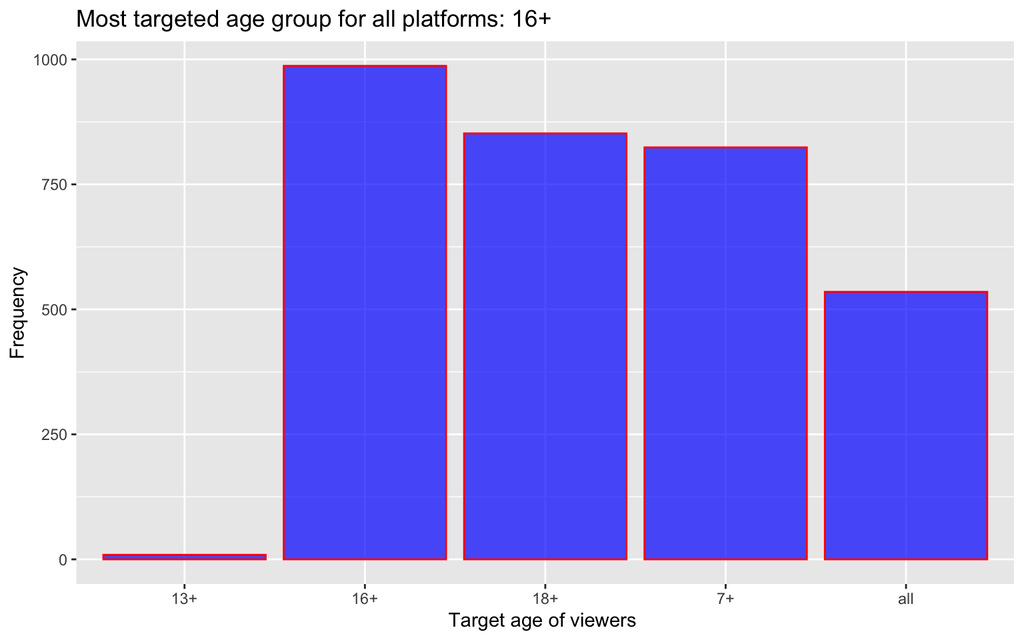

People who are 16 and older are the most targeted age groups for TV shows among all streaming platforms.

## 3.2 Smart Question: Which year published the highest number of TV shows?

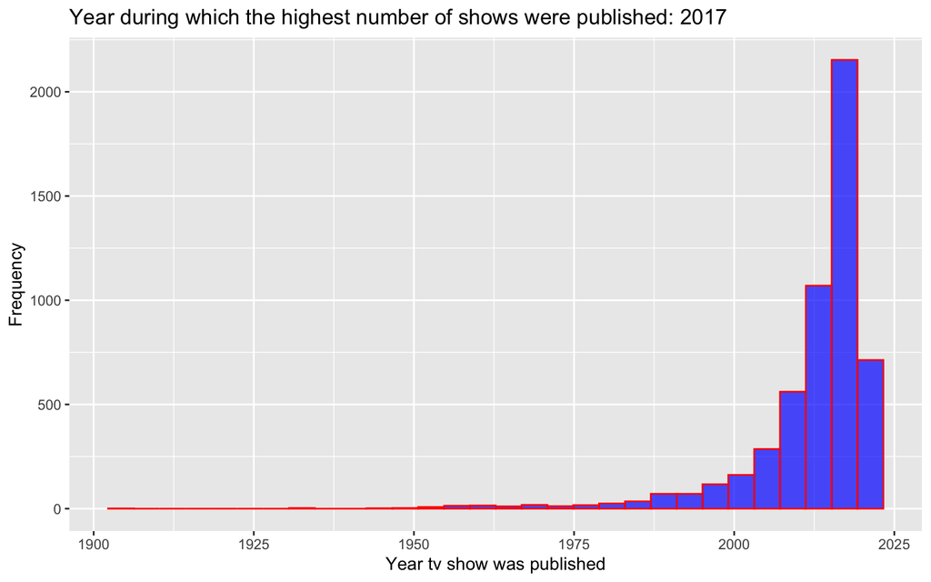

## 3.3 Rating Systems

### 3.3.1 Frequency of Ratings

First, we wanted to use exploratory data analysis (EDA) to learn more about the two rating systems: IMDb and Rotten Tomatoes.

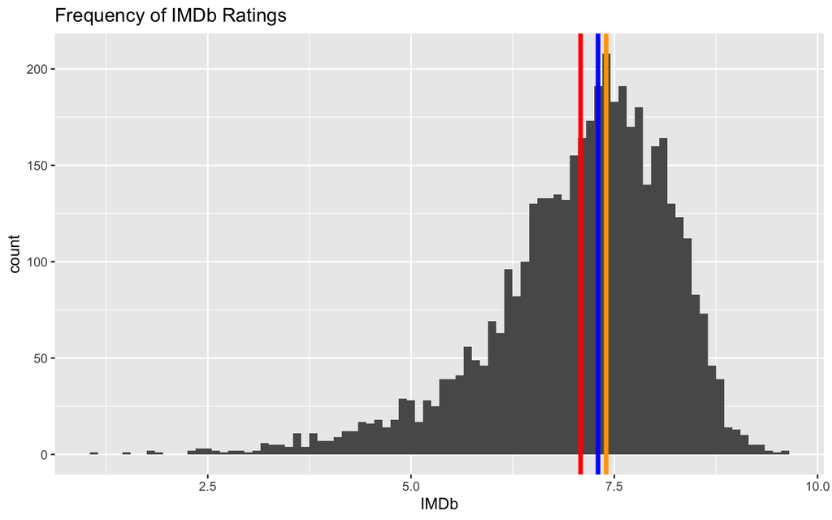

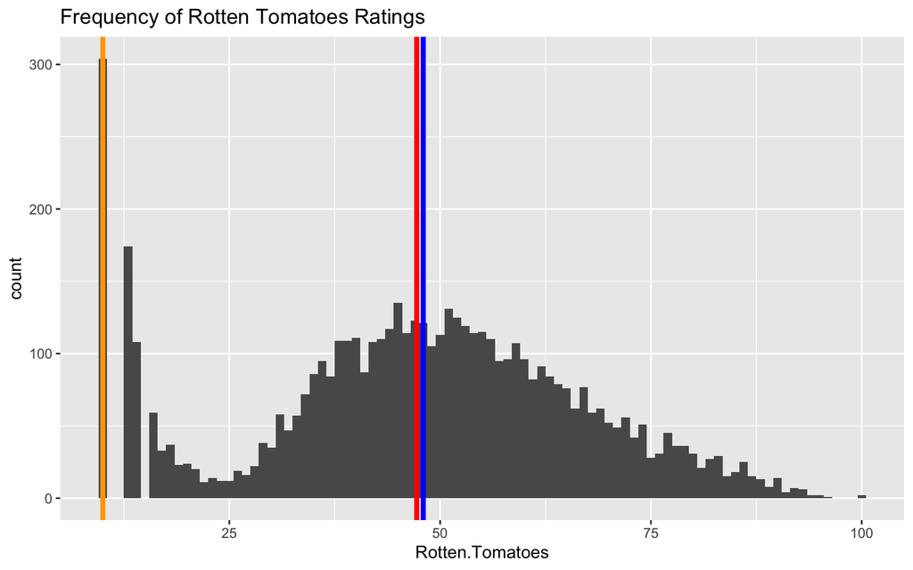

|  | IMDb rating | Rotten.Tomatoes rating |
| --- | --- | --- |
| Mean | 7.086 | 47.22 |
| Median | 7.3 | 48 |
| Mode | 7.4 | 10 |

IMDb is a rating scale from 1 to 10, but the lowest rating on this list is 1.1 and the highest is 9.6. Rotten Tomatoes rates TV shows on a scale from 1-100 with a lowest score of 10 and a highest score of 100. As seen in the histogram plot, the distribution of IMDb ratings has a slight left skew. This is further exemplified by the fact that the median (blue) is larger than the mean (red). The Rotten Tomatoes ratings mean and median are almost equal, but there are some outliers in the data at the lower end of the rating system. The mode is a 10/100 with 304 shows receiving that rating. The Rotten Tomatoes rating is a combination of critics’ ratings and audience ratings, but this data set only shows the total rating, which is a limitation of this dataset. It would have been interesting to see how critics and the audience agree or disagree about certain ratings. In comparing these ratings distribution, it became obvious that IMDb, on average, gives higher ratings than Rotten Tomatoes. IMDb has a mean of 7.09/10 (70.9%) and a median of 7.3/10 (73%) while Rotten Tomatoes has a mean of 47.2/100 (47.2%) and a median of 48/100 (48%). This discrepancy was surprising since we expected the rating systems to generally agree.

### 3.3.2 Comparison of Rating Systems

In order to further explore this unexpected discrepancy, we created a scatter plot comparing IMDb and Rotten Tomatoes. We also added the dimension of Age, which is the intended age group of each show. This allows us to visualize how shows for different age groups are rated.

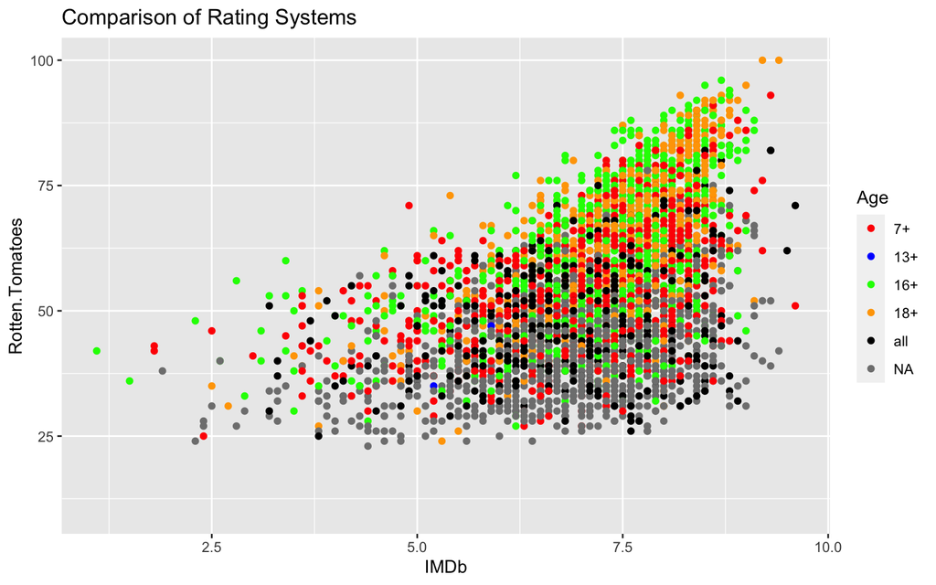

|  | Mean IMDb rating | Mean Rotten.Tomatoes rating |
| --- | --- | --- |
| 7+ | 7.013 | 55.031 |
| 13+ | 6.833 | 54.222 |
| 16+ | 7.248 | 60.307 |
| 18+ | 7.297 | 62.667 |
| all | 6.853 | 47.661 |
| NA | 6.959 | 31.701 |

This scatter plot further confirmed the fact that IMDb had higher ratings when compared to Rotten Tomatoes. There is a positive correlation between the two rating systems, but Rotten Tomatoes consistently has a lower overall rating. This helped us to form a new SMART question: what is the relationship between IMDb and Rotten Tomatoes?

## 3.4 Streaming Platforms

### 3.4.1 Ratings for Platforms

After comparing the rating systems to each other and then seeing how the intended age group affects ratings, we then turned to the different platforms. We compared the ratings for Disney, Hulu, Netflix, and Prime using boxplots.

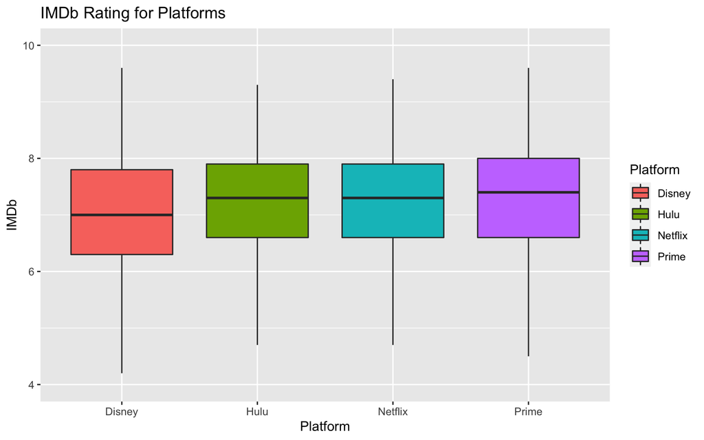

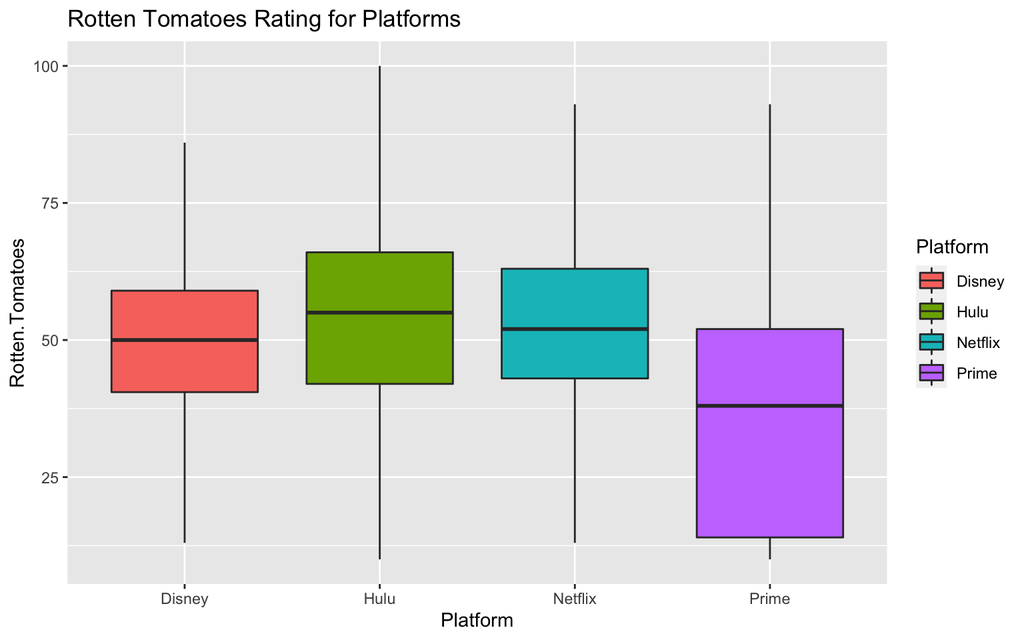

|  | Mean IMDb rating | Mean Rotten.Tomatoes rating |
| --- | --- | --- |
| Disney | 6.971 | 49.425 |
| Hulu | 7.082 | 52.838 |
| Netflix | 7.111 | 53.559 |
| Prime | 7.153 | 37.761 |

Much like how the rating systems had different overall distributions, they also painted different pictures for the average rating of shows on each platform. Using IMDb, Prime has the highest average rating of 7.15/10 and Disney has the lowest with 6.97/10. Looking at the Rotten Tomatoes ratings, however, Netflix has the highest average rating of 53.6/100, Hulu has the highest median score of 55/100, and Prime has the lowest average rating of 37.8/100. Prime is particularly interesting in this respect since it has the highest average rating with IMDb, but the lowest average rating with Rotten Tomatoes. This demonstrates that the question of “which platform has the highest average rating?” is not so straightforward.

### 3.4.2 Age Groups by Platform

Next, we considered the relationship between platform and target age group. The frequency of target age groups differed significantly between different streaming platforms, thus making this a relevant feature to consider in later analysis.

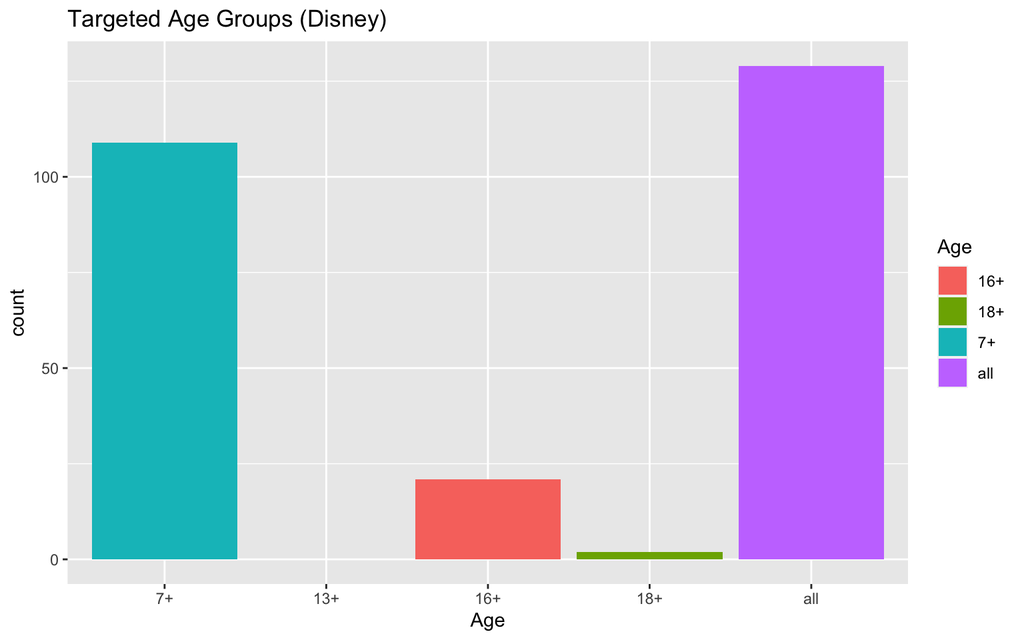

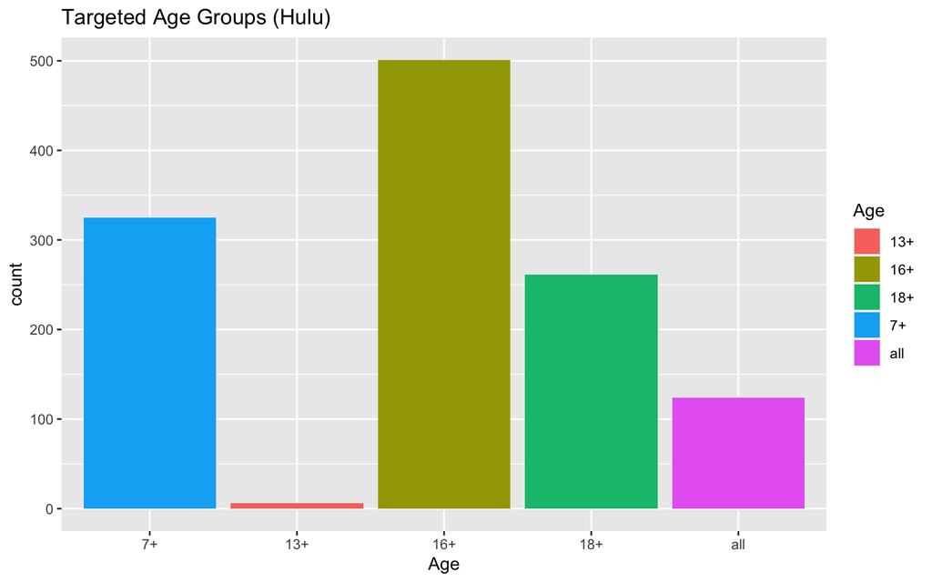

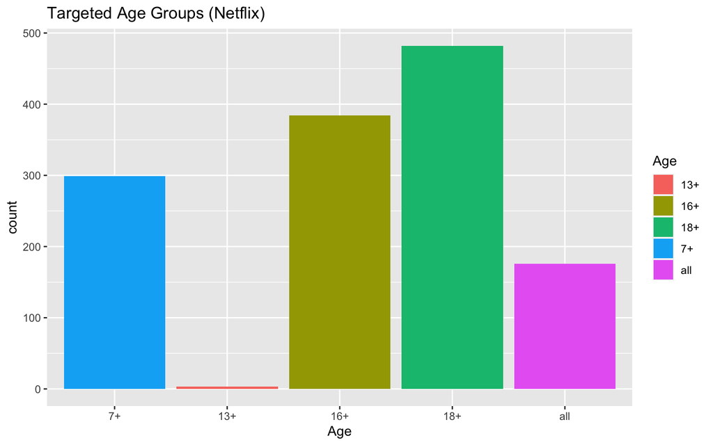

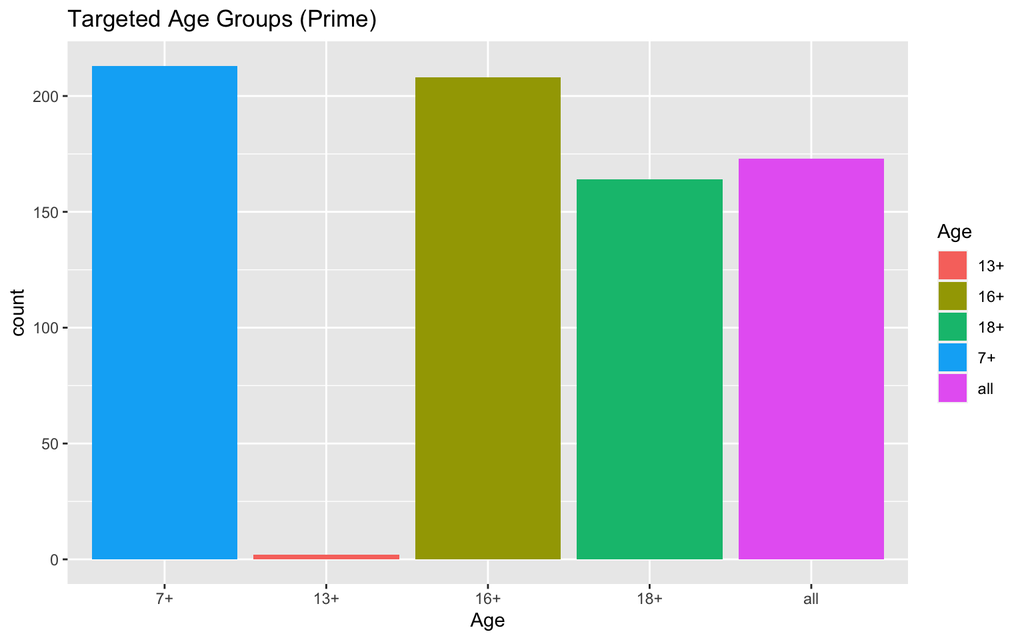

|  | Ratio |
| --- | --- |
| nrow(subset(disneytv, Age==“all”))/nrow(disneytv) | 0.368 |
| nrow(subset(hulutv, Age==“16+”))/nrow(hulutv) | 0.309 |
| nrow(subset(netflixtv, Age==“18+”))/nrow(netflixtv) | 0.245 |
| nrow(subset(primetv, Age==“7+”))/nrow(primetv) | 0.116 |

Starting with Disney, the most frequent targeted age group was all ages, with 36.8% of the Disney TV shows listed falling into that category. For Hulu, 16+ was the most common age group at 30.9%. The most common age group for Netflix was 18+, comprising 24.5% of its TV shows. Prime was more evenly distributed amongst age groups (apart from 13+, which was very low), but 7+ was the most common age group at 11.6%.

After seeing how much each streaming platform differed when it comes to age group, it would have been interesting to explore other demographics for the audience of each platform. Relevant datta in this respect could include gender, race, the number of views, and the actual age of the viewer (as opposed to the target age group). Since this data set did not include these features, this can be considered another limitation of the data. Our main focus was the TV show ratings, but we could have learned more about user preference and built a more detailed model with that additional information.

## 3.5 Normality Check for IMDb and Rotten Tomatoes

We have found the average value of IMDb and Rotten Tomatoes rating. Now, we want to check whether the samples of these two variables are normally distributed or not. If it is normally distributed the mean and median of the variable will be the same.

### 3.5.1 Normality Check for the Variables IMDb and Rotten Tomatoes for Netflix

```
##
##  Shapiro-Wilk normality test
##
## data:  netflixtv$IMDb
## W = 0.9, p-value <0.0000000000000002
```

```
##
##  Shapiro-Wilk normality test
##
## data:  netflixtv$Rotten.Tomatoes
## W = 1, p-value = 0.000000009
```

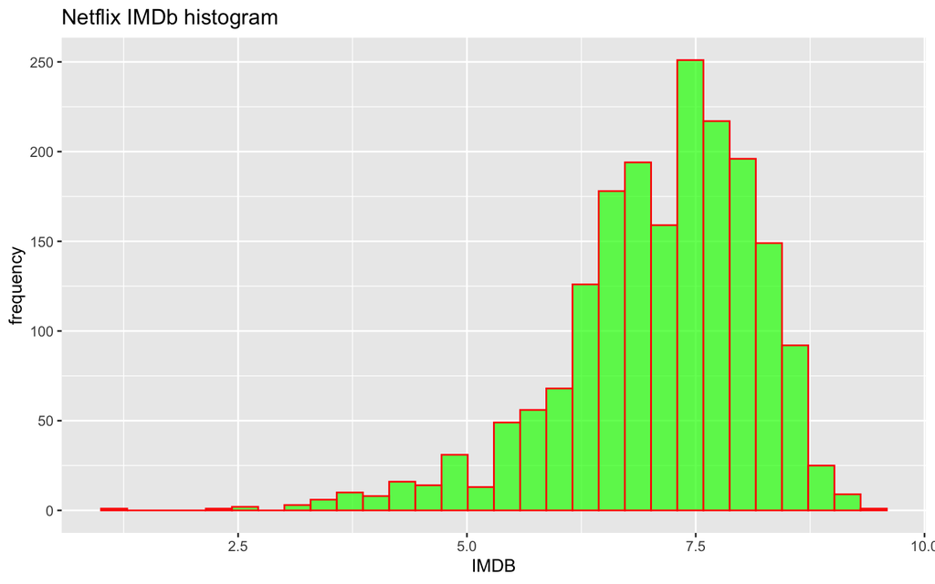

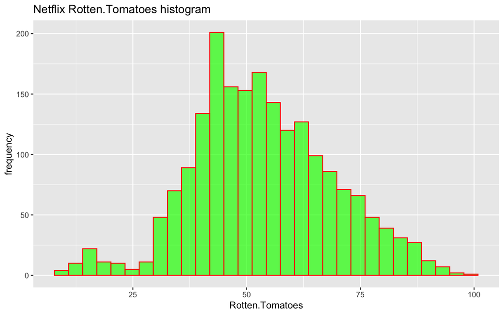

### 3.5.2 Normality Check for the Variables IMDb and Rotten Tomatoes for Hulu

```
##
##  Shapiro-Wilk normality test
##
## data:  hulutv$IMDb
## W = 0.9, p-value <0.0000000000000002
```

```
##
##  Shapiro-Wilk normality test
##
## data:  hulutv$Rotten.Tomatoes
## W = 1, p-value = 0.0000000000000006
```

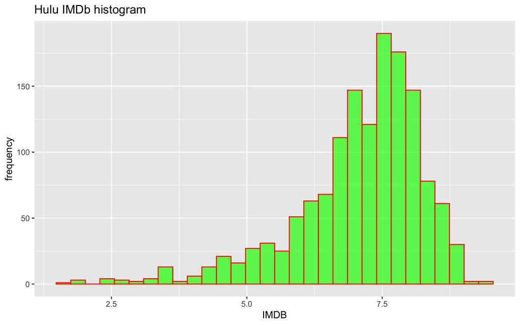

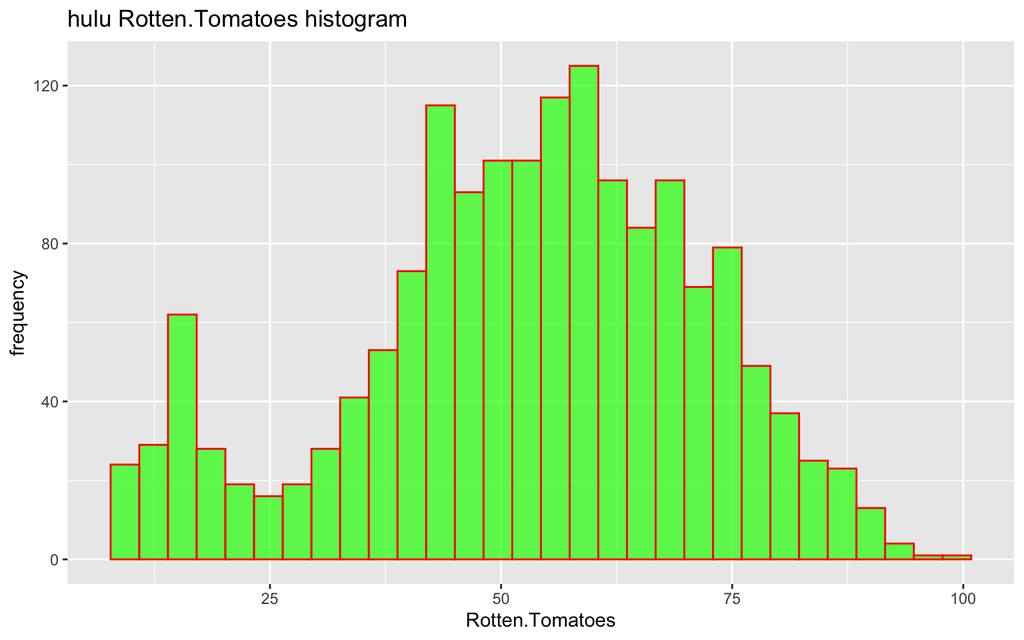

```
##
##  Shapiro-Wilk normality test
##
## data:  primetv$IMDb
## W = 0.9, p-value <0.0000000000000002
```

```
##
##  Shapiro-Wilk normality test
##
## data:  primetv$Rotten.Tomatoes
## W = 0.9, p-value <0.0000000000000002
```

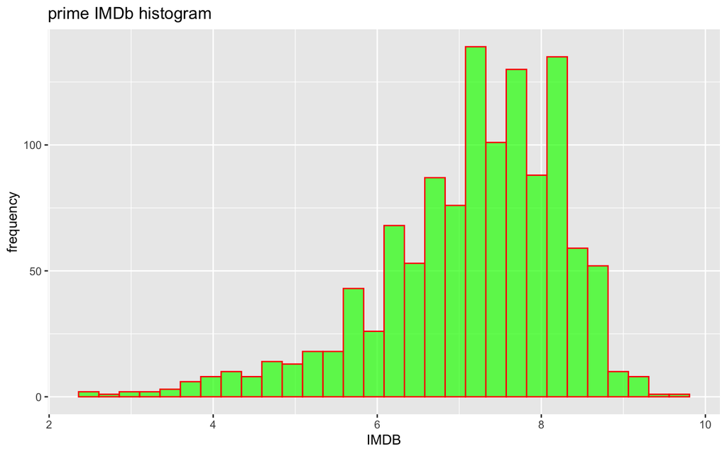

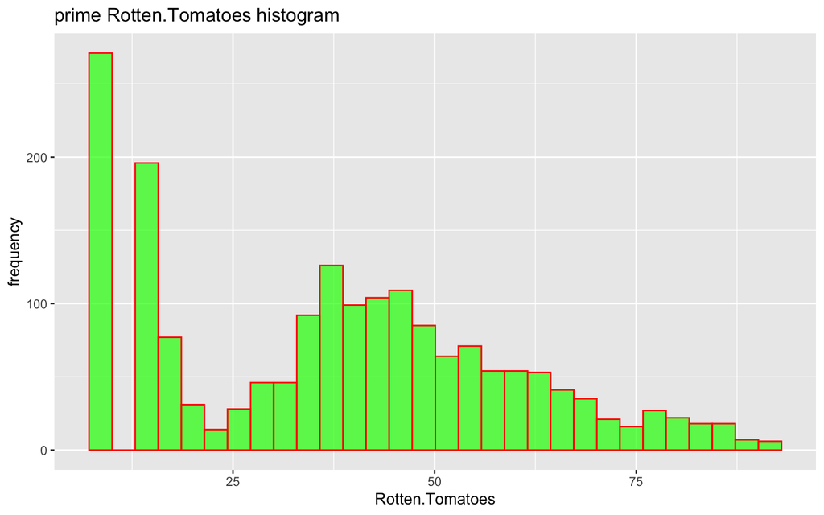

### 3.5.3 Normality Check for the Variables IMDb and Rotten Tomatoes for Disney+

```
##
##  Shapiro-Wilk normality test
##
## data:  disneytv$IMDb
## W = 1, p-value = 0.005
```

```
##
##  Shapiro-Wilk normality test
##
## data:  disneytv$Rotten.Tomatoes
## W = 1, p-value = 0.00009
```

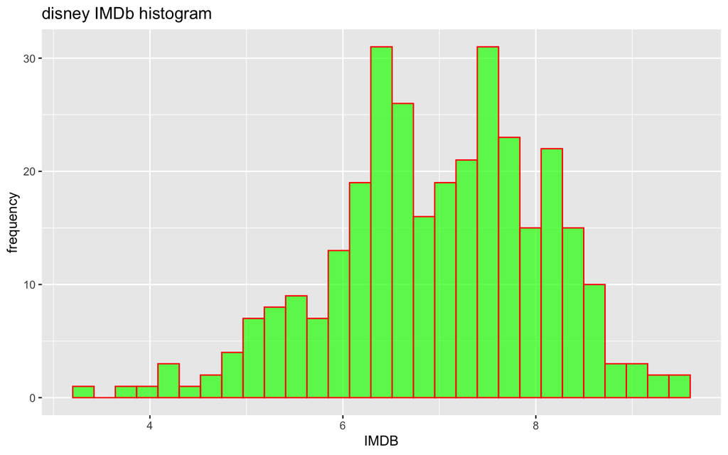

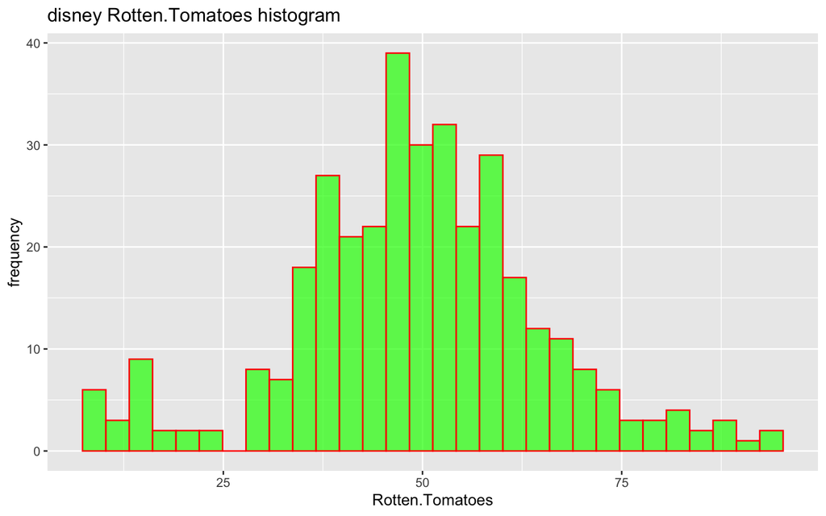

## 3.6 SMART Questions

After an initial examination of our chosen data set, we decided on three SMART questions to focus on:

What are the most targeted age groups for the TV shows by Netflix, Hulu, PrimeVideo, Disney+?

Which year published the highest number of TV shows?

Which streaming platform has the highest average rating (according to Rotten Tomatoes and IMDb)?

The first question focuses on the relation between the target age group and the platform. By looking at the distribution of the column Age for each platform, we can obtain knowledge about the intended audience for Netflix, Hulu, Prime, and Disney. The second question focuses on the column Year. We quickly noticed that the range of years listed was larger than expected, spanning from 1904 to 2021. We expected that more recent years would have more listed TV shows, but we wanted to explore that distribution in more detail. Finally, the third question looks at the IMDb and Rotten Tomatoes ratings for each platform. While there were some TV shows that were available on more than one platform, we were interested in seeing how the overall ratings were distributed for each platform.

During our exploratory data analysis, we also came up with a fourth SMART question:

What is the relationship between IMDb and Rotten Tomatoes?

We had not initially considered the idea that the IMDb and Rotten Tomatoes rating systems would differ by much, but more in-depth analysis revealed that there were significant differences between how the two systems rated shows. This created an additional dimension of analysis that we did not initially anticipate.

# 4 Distributions and Tests

## 4.1 Smart Question: Which streaming platform has the highest average rating (according to Rotten Tomatoes and IMDb)?

On our dataset, Netflix, Hulu, Prime tv, and Disney+ are our streaming platforms. To find the highest average rating according to Rotten Tomatoes and IMDb among the four streaming platforms a T-test is conducted. A t-test is a type of inferential statistic used to compare the means of two groups. By conducting t-test, average rating value (mean value) of all streaming platforms was found. Mean values from t-test are analyzed to find the highest average rating value.

```
##
##  Welch Two Sample t-test
##
## data:  netflixtv$IMDb and netflixtv$Rotten.Tomatoes
## t = -134, df = 1990, p-value <0.0000000000000002
## alternative hypothesis: true difference in means is not equal to 0
## 95 percent confidence interval:
##  -47.1 -45.8
## sample estimates:
## mean of x mean of y
##      7.11     53.56
```

```
##
##  Welch Two Sample t-test
##
## data:  hulutv$IMDb and hulutv$Rotten.Tomatoes
## t = -98, df = 1635, p-value <0.0000000000000002
## alternative hypothesis: true difference in means is not equal to 0
## 95 percent confidence interval:
##  -46.7 -44.8
## sample estimates:
## mean of x mean of y
##      7.08     52.84
```

```
##
##  Welch Two Sample t-test
##
## data:  primetv$IMDb and primetv$Rotten.Tomatoes
## t = -62, df = 1846, p-value <0.0000000000000002
## alternative hypothesis: true difference in means is not equal to 0
## 95 percent confidence interval:
##  -31.6 -29.6
## sample estimates:
## mean of x mean of y
##      7.15     37.76
```

```
##
##  Welch Two Sample t-test
##
## data:  disneytv$IMDb and disneytv$Rotten.Tomatoes
## t = -51, df = 354, p-value <0.0000000000000002
## alternative hypothesis: true difference in means is not equal to 0
## 95 percent confidence interval:
##  -44.1 -40.8
## sample estimates:
## mean of x mean of y
##      6.97     49.42
```

Prime Video has the highest average IMDb rating, which is 7.152538. This among all streaming platforms. Netflix has the highest average Rotten Tomatoes rating which is 53.559107 among all streaming platforms.

### 4.1.1 SMART Question: Do the rating IMDb and Rotten Tomatoes depend on age variable?

We want to check if the rating of streaming platforms on IMDb and Rotten Tomatoes are somehow related to the age of the audience. We conduct a chi-square test to check whether IMDb and Rotten Tomatoes are independent. The following are the null and alternative hypothesis. H0: Age and rating are independent from each other. H1: Age and rating are not independent from each other.

## 4.2 Independence check for Netflix Platform

```
##
##       1.1 2.5 2.7 3.2 3.3 3.4 3.5 3.6 3.7 3.8 3.9  4 4.1 4.2 4.3 4.4 4.5 4.6
##   16+   1   0   0   0   0   1   2   0   0   0   0  0   0   0   0   1   1   2
##   18+   0   1   1   0   0   0   0   1   0   1   0  0   1   0   0   0   0   4
##   7+    0   0   0   0   0   0   0   1   1   1   1  0   1   2   2   0   1   0
##   all   0   0   0   1   2   0   0   0   1   1   1  1   0   1   0   1   1   1
##
##       4.7 4.8 4.9  5 5.1 5.2 5.3 5.4 5.5 5.6 5.7 5.8 5.9  6 6.1 6.2 6.3 6.4 6.5
##   16+   0   1   0  0   0   1   1   4   1   0   0   2   1  4   3   8   3   5   6
##   18+   1   1   1  5   1   0   3   5   3   6   4   5   8  5   6  15   7  17  16
##   7+    0   1   3  1   0   3   1   1   6   1   7   4   4  8   3   4   5   5  10
##   all   0   1   5  2   1   2   2   4   1   2   4   1   5  4   1   8   3   6   5
##
##       6.6 6.7 6.8 6.9  7 7.1 7.2 7.3 7.4 7.5 7.6 7.7 7.8 7.9  8 8.1 8.2 8.3 8.4
##   16+   8  13  12  11  7  17  21  13  29  21  14  24  17  13 18  19  11  16  13
##   18+  14  13  21  16 13  17  23  17  15  23  22  16  19  27 19   9  14  14  15
##   7+    9  11  10  10 15  10  12  11  13  15  12   5   8  10 12  12   7   9  10
##   all   8   7  10   7  2   6   7   4   8   5   3   5   4   2  4   4   2   2   2
##
##       8.5 8.6 8.7 8.8 8.9  9 9.1 9.3 9.4
##   16+  10   6   8   5   0  4   2   0   0
##   18+   9  11   6   6   1  1   1   0   1
##   7+    6   4   2   4   0  0   1   1   0
##   all   3   3   2   0   0  0   0   1   0
```

```
##
##  Pearson's Chi-squared test
##
## data:  contable1
## X-squared = 259, df = 192, p-value = 0.0009
```

```
##
##       16 21 22 23 27 29 30 31 32 33 34 35 36 37 38 39 40 41 42 43 44 45 46 47
##   16+  0  0  1  1  0  0  1  2  0  0  2  2  0  3  1  2  3  3  4  3  7  7  3  6
##   18+  0  0  1  0  0  0  1  1  0  0  1  2  2  0  2  4 11  1  6  6  9  7  6 11
##   7+   1  0  0  0  1  1  2  0  1  2  1  2  6  4  7  7 10  5  7  9  8 12  6  6
##   all  1  2  0  0  0  1  0  4  1  2  4  5  5  4  4 18 10  5  8  6 12  9  7  5
##
##       48 49 50 51 52 53 54 55 56 57 58 59 60 61 62 63 64 65 66 67 68 69 70 71
##   16+  9  4  8  7 12 10 14 17  8 11  6 12 13  6 17  9  7 15 10  9 10  7  8  8
##   18+  9  9 13  7 16 16  9  7 19 12 11  9 19 22  8 15 13 14 10 17  8  7 11 10
##   7+   7  8 10 12 12  8  8 12  6  8  4  5  7  8  4  9  7  7  4  7  3  8  4  3
##   all  6  5  5  5  6  8  2  2  2  4  1  2  0  1  3  3  1  1  0  1  0  0  0  1
##
##       72 73 74 75 76 77 78 79 80 81 82 83 84 85 86 87 88 89 90 92 93 94 95 96
##   16+  4 10  8  5  4  9  5  3  8  6  3  4  6  1  7  3  5  2  1  0  1  0  0  1
##   18+ 14  9  9  3  6  9  4  8  4  4  7  6  4  7  7  2  2  3  5  2  2  1  1  0
##   7+   3  3  3  1  1  5  1  2  2  1  2  2  0  1  1  0  0  0  1  0  1  0  0  0
##   all  0  0  0  2  0  0  0  0  1  0  1  0  0  0  0  0  0  0  0  0  0  0  0  0
##
##       100
##   16+   0
##   18+   1
##   7+    0
##   all   0
```

```
##
##  Pearson's Chi-squared test
##
## data:  contable2
## X-squared = 448, df = 216, p-value <0.0000000000000002
```

## 4.3 Independence Check for Hulu Platform

```
##
##  Pearson's Chi-squared test
##
## data:  contable3
## X-squared = 230, df = 207, p-value = 0.1
```

```
##
##  Pearson's Chi-squared test
##
## data:  contable4
## X-squared = 277, df = 210, p-value = 0.001
```

## 4.4 Independence Check for Prime TV Platform

```
##
##  Pearson's Chi-squared test
##
## data:  contable5
## X-squared = 186, df = 171, p-value = 0.2
```

```
##
##  Pearson's Chi-squared test
##
## data:  contable6
## X-squared = 320, df = 201, p-value = 0.0000002
```

## 4.5 Independence Check for Disney+ Platform

```
##
##  Pearson's Chi-squared test
##
## data:  contable7
## X-squared = 246, df = 156, p-value = 0.000006
```

```
##
##  Pearson's Chi-squared test
##
## data:  contable8
## X-squared = 227, df = 180, p-value = 0.01
```

Since the p-value for IMDB is 0.000006, and p-value for Rotten Tomatoes is 0.01, which are both lower than 0.05, we need to reject the null hypothesis. Thus, IMDb and Rotten Tomatoes ratings for Diseney+ are not independent, meaning Age and rating are correlated for Disney+ platform.

# 5 Multiple Linear Regression Model

## 5.1 SMART Question: What is the relationship between IMDb and Rotten Tomatoes?

### 5.1.1 Preparation Work

#### 5.1.1.1 Dropping NaN Data and Building Histograms

To analyze the score relationships between two platforms, we need to drop the rows that have no IMDb scores and no Rotten.Tomatoes scores. Additionally, the column of X, ID, Title and Type are useless, so we also drop these columns. After we finished the preparation work, Let’s have a look.

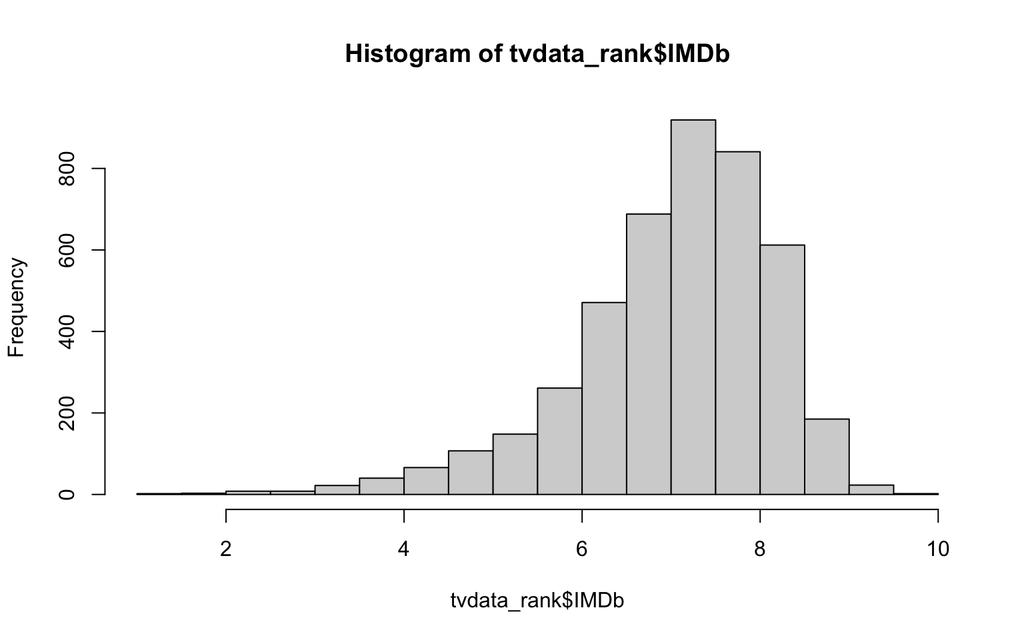

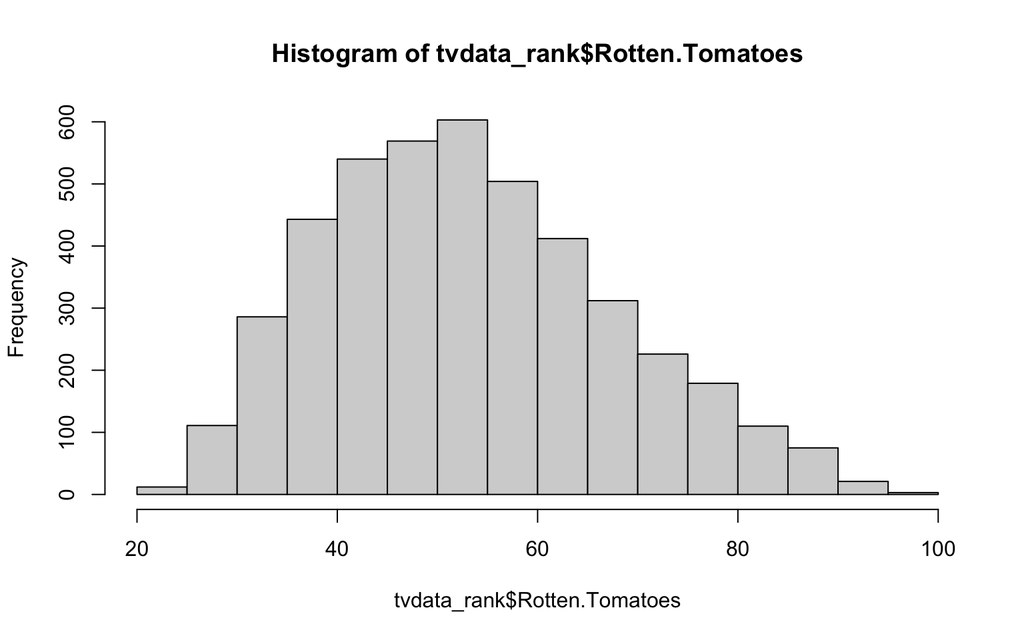

#### 5.1.1.2 Plotting a pairs() with all the Variables (Quantitative and Qualitative)

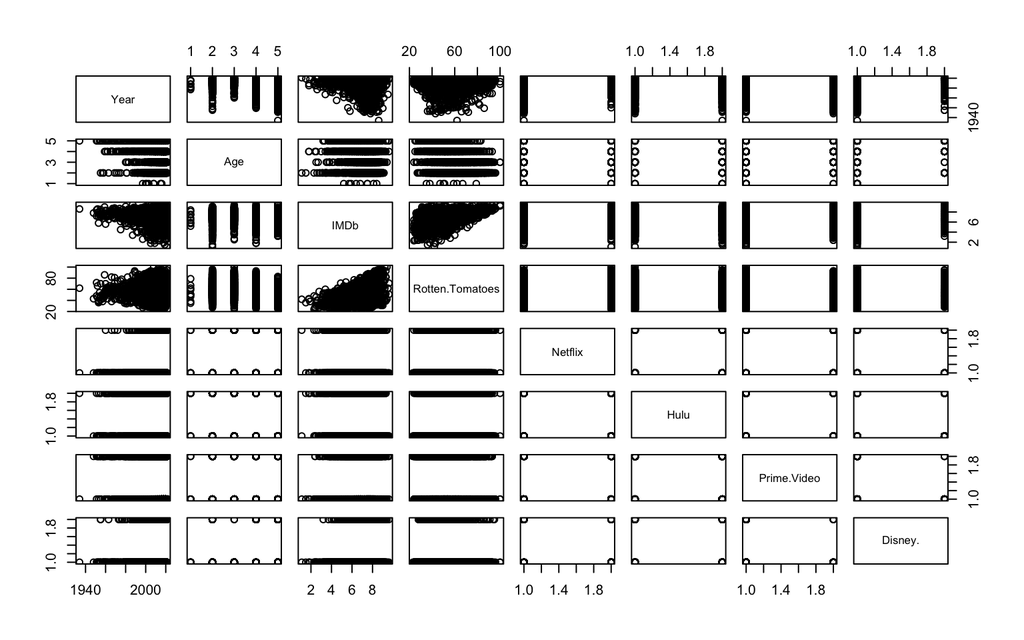

#### 5.1.1.3 Plotting a corrplot() with Only the Numerical Variables

[figure not shown]

### 5.1.2 Builsing the Linear Regression Model

#### 5.1.2.1 Simple Linear Model

By using the variable Rotten.Tomatoes only, we built a linear model with 1 independent variable to predict the IMDb.

```
##
## Call:
## lm(formula = IMDb ~ Rotten.Tomatoes, data = tvdata_rank)
##
## Residuals:
##    Min     1Q Median     3Q    Max
## -5.562 -0.495  0.087  0.628  2.746
##
## Coefficients:
##                 Estimate Std. Error t value            Pr(>|t|)
## (Intercept)      5.15419    0.05785    89.1 <0.0000000000000002 ***
## Rotten.Tomatoes  0.03590    0.00104    34.6 <0.0000000000000002 ***
## ---
## Signif. codes:  0 '***' 0.001 '**' 0.01 '*' 0.05 '.' 0.1 ' ' 1
##
## Residual standard error: 0.989 on 4404 degrees of freedom
## Multiple R-squared:  0.213,  Adjusted R-squared:  0.213
## F-statistic: 1.19e+03 on 1 and 4404 DF,  p-value: <0.0000000000000002
```

Model (num): IMDb ~ Rotten.Tomatoes

|  | Estimate | Std. Error | t value | Pr(>\|t\|) |
| --- | --- | --- | --- | --- |
| (Intercept) | 5.1542 | 0.0579 | 89.1 | 0 |
| Rotten.Tomatoes | 0.0359 | 0.0010 | 34.6 | 0 |

#### 5.1.2.2 Adding a Variable

Because there is only a weak correlation, We tried to add the other variables into the model. Below is the result:

```
##
## Call:
## lm(formula = IMDb ~ ., data = tvdata_rank)
##
## Residuals:
##    Min     1Q Median     3Q    Max
## -5.361 -0.465  0.080  0.586  2.579
##
## Coefficients:
##                 Estimate Std. Error t value             Pr(>|t|)
## (Intercept)     13.68924    3.61092    3.79              0.00015 ***
## Year            -0.00449    0.00178   -2.52              0.01194 *
## Age16+           0.14321    0.30940    0.46              0.64349
## Age18+           0.07727    0.31010    0.25              0.80323
## Age7+            0.11428    0.30955    0.37              0.71201
## Ageall           0.22263    0.31096    0.72              0.47409
## Rotten.Tomatoes  0.04290    0.00131   32.72 < 0.0000000000000002 ***
## Netflix1        -0.10325    0.05598   -1.84              0.06521 .
## Hulu1           -0.24195    0.05480   -4.42              0.00001 ***
## Prime.Video1     0.09515    0.05565    1.71              0.08740 .
## Disney.1        -0.24240    0.07845   -3.09              0.00202 **
## ---
## Signif. codes:  0 '***' 0.001 '**' 0.01 '*' 0.05 '.' 0.1 ' ' 1
##
## Residual standard error: 0.923 on 3196 degrees of freedom
##   (1199 observations deleted due to missingness)
## Multiple R-squared:  0.285,  Adjusted R-squared:  0.283
## F-statistic:  128 on 10 and 3196 DF,  p-value: <0.0000000000000002
```

We can see that the adjusted correlation coefficient increases, but some variables are not significant, so try we then tried to drop it.

#### 5.1.2.3 Dropping Sparse Age Observations

```
##
## 13+ 16+ 18+  7+ all
##   9 987 852 824 535
```

#### 5.1.2.4 Linear Model with Three Variables

From the previous results, we then made the third model as follow.

```
##
## Call:
## lm(formula = IMDb ~ ., data = tvdata_rank_no13)
##
## Residuals:
##    Min     1Q Median     3Q    Max
## -5.417 -0.467  0.087  0.585  2.756
##
## Coefficients:
##                 Estimate Std. Error t value             Pr(>|t|)
## (Intercept)     18.52238    3.47216    5.33          0.000000102 ***
## Year            -0.00681    0.00172   -3.97          0.000074207 ***
## Age18+          -0.06490    0.04422   -1.47                 0.14
## Age7+           -0.05724    0.04503   -1.27                 0.20
## Ageall           0.03145    0.05450    0.58                 0.56
## Rotten.Tomatoes  0.04195    0.00130   32.30 < 0.0000000000000002 ***
## Hulu1           -0.20024    0.03555   -5.63          0.000000019 ***
## ---
## Signif. codes:  0 '***' 0.001 '**' 0.01 '*' 0.05 '.' 0.1 ' ' 1
##
## Residual standard error: 0.927 on 3191 degrees of freedom
## Multiple R-squared:  0.277,  Adjusted R-squared:  0.276
## F-statistic:  204 on 6 and 3191 DF,  p-value: <0.0000000000000002
```

Model (num): IMDb ~ Year + Age + Rotten.Tomatoes + Hulu

|  | Estimate | Std. Error | t value | Pr(>\|t\|) |
| --- | --- | --- | --- | --- |
| (Intercept) | 18.5224 | 3.4722 | 5.335 | 0.0000 |
| Year | -0.0068 | 0.0017 | -3.968 | 0.0001 |
| Age18+ | -0.0649 | 0.0442 | -1.468 | 0.1423 |
| Age7+ | -0.0572 | 0.0450 | -1.271 | 0.2038 |
| Ageall | 0.0315 | 0.0545 | 0.577 | 0.5639 |
| Rotten.Tomatoes | 0.0420 | 0.0013 | 32.300 | 0.0000 |
| Hulu1 | -0.2002 | 0.0355 | -5.633 | 0.0000 |

VIFs of the model

| Age18+ | Age7+ | Ageall | Hulu1 | Rotten.Tomatoes | Year |
| --- | --- | --- | --- | --- | --- |
| 1.17 | 1.42 | 1.44 | 1.54 | 1.2 | 1.1 |

#### 5.1.2.5 Rebuilding Linear Regression Model

```
##
## Call:
## lm(formula = IMDb ~ Rotten.Tomatoes, data = tvdata_rank_no13)
##
## Residuals:
##    Min     1Q Median     3Q    Max
## -5.396 -0.459  0.075  0.581  2.811
##
## Coefficients:
##                 Estimate Std. Error t value            Pr(>|t|)
## (Intercept)       4.7863     0.0709    67.5 <0.0000000000000002 ***
## Rotten.Tomatoes   0.0407     0.0012    34.0 <0.0000000000000002 ***
## ---
## Signif. codes:  0 '***' 0.001 '**' 0.01 '*' 0.05 '.' 0.1 ' ' 1
##
## Residual standard error: 0.934 on 3196 degrees of freedom
## Multiple R-squared:  0.266,  Adjusted R-squared:  0.266
## F-statistic: 1.16e+03 on 1 and 3196 DF,  p-value: <0.0000000000000002
```

Model (num): IMDb ~ Rotten.Tomatoes

|  | Estimate | Std. Error | t value | Pr(>\|t\|) |
| --- | --- | --- | --- | --- |
| (Intercept) | 4.7863 | 0.0709 | 67.5 | 0 |
| Rotten.Tomatoes | 0.0407 | 0.0012 | 34.0 | 0 |

The concepts above can be extended naturally to models with interactions between numeric and factor variables.

```
##
## Call:
## lm(formula = IMDb ~ . + Rotten.Tomatoes:Age, data = tvdata_rank_no13)
##
## Residuals:
##    Min     1Q Median     3Q    Max
## -5.460 -0.457  0.069  0.579  2.788
##
## Coefficients:
##                        Estimate Std. Error t value             Pr(>|t|)
## (Intercept)            20.68621    3.51095    5.89         0.0000000042 ***
## Year                   -0.00781    0.00174   -4.49         0.0000073150 ***
## Age18+                 -0.45763    0.20041   -2.28               0.0225 *
## Age7+                  -0.52436    0.20025   -2.62               0.0089 **
## Ageall                  0.58862    0.23340    2.52               0.0117 *
## Rotten.Tomatoes         0.03930    0.00218   18.03 < 0.0000000000000002 ***
## Hulu1                  -0.20345    0.03549   -5.73         0.0000000108 ***
## Age18+:Rotten.Tomatoes  0.00639    0.00317    2.01               0.0440 *
## Age7+:Rotten.Tomatoes   0.00814    0.00340    2.39               0.0168 *
## Ageall:Rotten.Tomatoes -0.01237    0.00445   -2.78               0.0055 **
## ---
## Signif. codes:  0 '***' 0.001 '**' 0.01 '*' 0.05 '.' 0.1 ' ' 1
##
## Residual standard error: 0.924 on 3188 degrees of freedom
## Multiple R-squared:  0.283,  Adjusted R-squared:  0.281
## F-statistic:  140 on 9 and 3188 DF,  p-value: <0.0000000000000002
```

Model (num): IMDb ~ Year + Age + Rotten.Tomatoes + Hulu + Rotten.Tomatoes:Age

|  | Estimate | Std. Error | t value | Pr(>\|t\|) |
| --- | --- | --- | --- | --- |
| (Intercept) | 20.6862 | 3.5110 | 5.89 | 0.0000 |
| Year | -0.0078 | 0.0017 | -4.49 | 0.0000 |
| Age18+ | -0.4576 | 0.2004 | -2.28 | 0.0225 |
| Age7+ | -0.5244 | 0.2003 | -2.62 | 0.0089 |
| Ageall | 0.5886 | 0.2334 | 2.52 | 0.0117 |
| Rotten.Tomatoes | 0.0393 | 0.0022 | 18.03 | 0.0000 |
| Hulu1 | -0.2034 | 0.0355 | -5.73 | 0.0000 |
| Age18+:Rotten.Tomatoes | 0.0064 | 0.0032 | 2.02 | 0.0440 |
| Age7+:Rotten.Tomatoes | 0.0081 | 0.0034 | 2.39 | 0.0168 |
| Ageall:Rotten.Tomatoes | -0.0124 | 0.0045 | -2.78 | 0.0055 |

#### 5.1.2.6 Comparison with the Three Models

```
## Analysis of Variance Table
##
## Model 1: IMDb ~ Rotten.Tomatoes
## Model 2: IMDb ~ Year + Age + Rotten.Tomatoes + Hulu
## Model 3: IMDb ~ Year + Age + Rotten.Tomatoes + Hulu + Rotten.Tomatoes:Age
##   Res.Df  RSS Df Sum of Sq    F       Pr(>F)
## 1   3196 2787
## 2   3191 2744  5      43.2 10.1 0.0000000013 ***
## 3   3188 2724  3      20.2  7.9 0.0000300757 ***
## ---
## Signif. codes:  0 '***' 0.001 '**' 0.01 '*' 0.05 '.' 0.1 ' ' 1
```

ANOVA comparison between the models

| Res.Df | RSS | Df | Sum of Sq | F | Pr(>F) |
| --- | --- | --- | --- | --- | --- |
| 3196 | 2787 | NA | NA | NA | NA |
| 3191 | 2744 | 5 | 43.2 | 10.1 | 0 |
| 3188 | 2724 | 3 | 20.2 | 7.9 | 0 |

With one interaction added, the full model seems quite nice, although it’s still a weak correlation.

## 5.3 Problem and Future Research

### 5.3.1 Weak Correlation

The weak correlation between IMDb and Rotten Tomatoes means that there are other variables that we still don’t know. To find other variables that influence the results can be a focus of future researches

### 5.3.2 Left-Skewed IMDb

As the IMDb histogram above is a little left-skewed, it means there are many outliers. While we built the model, we did not exclude the outliers as we considered these values important.

# 6 Conclusion

The independent variables we were considering include the target age group and the straming platform. Our depenent variable was the TV show rating, including both IMDb and Rotten Tomatoes. Our analysis provided insights into people’s preference of TV shows in different platforms.

After data cleaning and EDA on most variables in the dataset, we found that 16+ is the most targeted age for TV shows, followed by 18+, which means the most target people is adolescence and young adults.

Looking at the years during which TV shows were released, more and more TV shows are created in recent years and 2017 is the peak. There were very new shows produced during the 20th century, a majority listed were created in the past 20 years.

As we proceeded with hypothesis analysis of different platforms and ratings, we found that IMDb has higher average rating than Rotten Tomatoes and there is only a weak correlation betwween the two rating systems. There is a positive correlation between IMDb and Rotten Tomatoes, but they have different distributions overall: IMDb has a higher average and is left skewed while Rotten Tomatoes tends to be lower and has low-value outliers. In addition to that, IMDb and Rotten Tomatoes disagree about the highest rated platforms. Using IMDb, Prime has both the highest mean and median rating. According to Rotten Tomatoes, however, Prime has the lowest rating, Hulu has the highest median rating, and Netflix has the highest mean rating.

As we were exploring possible linear models, relating the rating systems to platform, age group, and year of creation, we found a correlation between age and Rotten Tomatoes using a linear model. This relation can be seen in our final results.

# 7 References

Kaggle, “Movies on Netflix, Prime Video, Hulu and Disney+. A collection of movies found on these streaming platforms”, Mar 1 2020, https://www.kaggle.com/ruchi798/movies-on-netflix-prime-video-hulu-and-disney

Statista, 2021, “Market shares of selected Subscription video-on-demand (SVOD) services in the United States in 2020”. Mar 1 2020, https://www.statista.com/statistics/496011/usa-svod-to-tv-streaming-usage/

The Verge, 2020“In a streaming wars world, JustWatch has become an essential tool” Mar 1 2020, https://www.theverge.com/2020/6/18/21291519/justwatch-streaming-search-engine-filter-app-impressions-hbo-max-disney-plus-netflix-hulu